# Data 524 Assignment 2

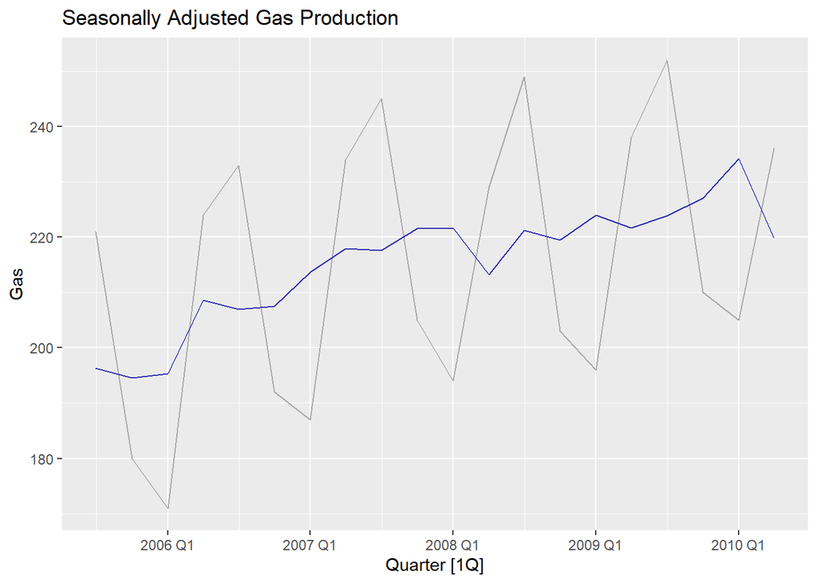

```r
# C
gas_season <- gas %>% model(classical_decomposition(Gas, type = "multiplicative"))
components(gas_season) %>%
  as_tsibble() %>%
  autoplot(Gas, colour = "darkgray") +
  geom_line(aes(y=season_adjust), colour = "#3230B2") +
  labs(title = "Seasonally Adjusted Gas Production")
```

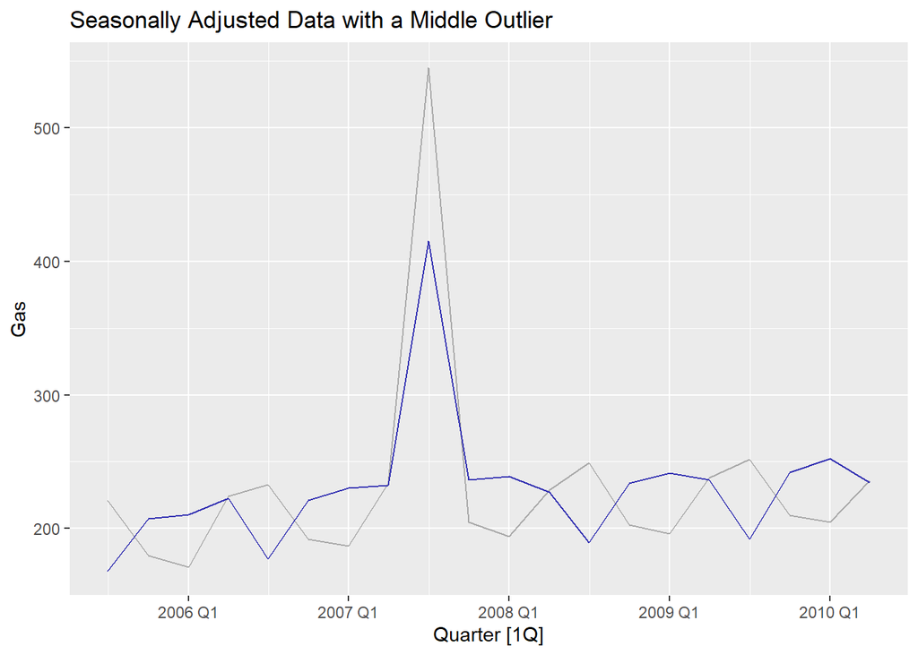

```r
# F
gas$Gas[gas$Gas == 471] <- gas$Gas[gas$Gas == 471] - 300
gas$Gas[gas$Gas == 245] <- gas$Gas[gas$Gas == 245] + 300

gas %>%
  model(classical_decomposition(Gas, type = "multiplicative")) %>%
  components() %>%
  as_tsibble() %>%
  autoplot(Gas, colour = "darkgray") +
  geom_line(aes(y=season_adjust), colour = "#3230B2") +
  labs(title = "Seasonally Adjusted Data with a Middle Outlier")
```

The results align with Part A. The seasonal line shows a trough at the beginning of the year, followed by peaks around mid-year, and then a gradual decline toward the end of the year.

The first graph displays **Australia’s gas production** over time, revealing a clear **seasonal pattern** with peaks and troughs recurring each year. The second graph shows the **classical multiplicative decomposition**, breaking the time series into its **trend-cycle, seasonal, and random components**. The trend component indicates an **upward trend**, while the seasonal component confirms the **recurring fluctuations** observed in the first graph. These results support the initial graphical interpretation. The third graph represents the **seasonally adjusted gas production**, where the seasonal component has been removed, making the underlying trend more visible. The final graph introduces an **outlier in the middle of the time series**, which significantly disrupts the seasonally adjusted data, causing a sharp spike. This highlights the **sensitivity of time series decomposition to outliers**. If the outlier were placed at the end instead of the middle, its effect might be less noticeable on the overall trend estimation but would still distort the recent data, affecting short-term forecasts.

**Exercise 3.8**

Recall your retail time series data (from Exercise 7 in Section 2.10). Decompose the series using X-11. Does it reveal any outliers, or unusual features that you had not noticed previously?

```r
#x11_dcmp <- myts %>%
 # model(x11 = X_13ARIMA_SEATS(Turnover ~ x11())) %>%
 # components()
#autoplot(x11_dcmp) +
 # labs(title = "Decomposition of total US retail employment using X-11.")
```

[output not shown]